# P8105_HW3_rs4788

Ruhui Shen

2025-10-12

```r
library(tidyverse)
library(viridis)
library(tidyr)
library(janitor)
```

```r
library(patchwork)
library(ggplot2)
library(dplyr)
```

# Problem 1

### First load the data:

```r
library(p8105.datasets)
data("instacart")
glimpse(instacart)
```

```
## Rows: 1,384,617
## Columns: 15
## $ order_id               <int> 1, 1, 1, 1, 1, 1, 1, 1, 36, 36, 36, 36, 36, 36,…
## $ product_id             <int> 49302, 11109, 10246, 49683, 43633, 13176, 47209…
## $ add_to_cart_order      <int> 1, 2, 3, 4, 5, 6, 7, 8, 1, 2, 3, 4, 5, 6, 7, 8,…
## $ reordered              <int> 1, 1, 0, 0, 1, 0, 0, 1, 0, 1, 0, 1, 1, 1, 1, 1,…
## $ user_id                <int> 112108, 112108, 112108, 112108, 112108, 112108,…
## $ eval_set               <chr> "train", "train", "train", "train", "train", "t…
## $ order_number           <int> 4, 4, 4, 4, 4, 4, 4, 4, 23, 23, 23, 23, 23, 23,…
## $ order_dow              <int> 4, 4, 4, 4, 4, 4, 4, 4, 6, 6, 6, 6, 6, 6, 6, 6,…
## $ order_hour_of_day      <int> 10, 10, 10, 10, 10, 10, 10, 10, 18, 18, 18, 18,…
## $ days_since_prior_order <int> 9, 9, 9, 9, 9, 9, 9, 9, 30, 30, 30, 30, 30, 30,…
## $ product_name           <chr> "Bulgarian Yogurt", "Organic 4% Milk Fat Whole …
## $ aisle_id               <int> 120, 108, 83, 83, 95, 24, 24, 21, 2, 115, 53, 1…
## $ department_id          <int> 16, 16, 4, 4, 15, 4, 4, 16, 16, 7, 16, 4, 16, 2…
## $ aisle                  <chr> "yogurt", "other creams cheeses", "fresh vegeta…
## $ department             <chr> "dairy eggs", "dairy eggs", "produce", "produce…
```

### Take a look at the data:

```r
instacart_summary =
  instacart %>%
  summarise(
    n_obs = n(),
    n_vars = ncol(.),
    n_users = n_distinct(user_id),
    n_orders = n_distinct(order_id),
    n_products = n_distinct(product_id),
    n_aisles = n_distinct(aisle),
    n_departments = n_distinct(department)
  )

instacart_summary
```

```
## # A tibble: 1 × 7
##     n_obs n_vars n_users n_orders n_products n_aisles n_departments
##     <int>  <int>   <int>    <int>      <int>    <int>         <int>
## 1 1384617     15  131209   131209      39123      134            21
```

This dataset records orders and products information from the Instacart platform, describing items within specific orders. It contains 1,384,617 observations across 15 variables, covering 131,209 users and 131,209 orders. The dataset includes 39,123 distinct products distributed across 134 aisles and 21 departments.

### Let’s make more detailed description:

#### aisles_items:

```r
aisle_counts =
  instacart %>%
  count(aisle, name = "n_items") %>%
  arrange(desc(n_items))
aisle_counts
```

```
## # A tibble: 134 × 2
##    aisle                         n_items
##    <chr>                           <int>
##  1 fresh vegetables               150609
##  2 fresh fruits                   150473
##  3 packaged vegetables fruits      78493
##  4 yogurt                          55240
##  5 packaged cheese                 41699
##  6 water seltzer sparkling water   36617
##  7 milk                            32644
##  8 chips pretzels                  31269
##  9 soy lactosefree                 26240
## 10 bread                           23635
## # ℹ 124 more rows
```

There are 134 aisles. In terms of order times, fresh vegetables and fresh fruits are much higher than other aisles, with packaged vegetables and fruits ranking third. This demonstrates the high demand for fruits and vegetables, which are essential daily necessities.

#### Plot for aisle & items_number:

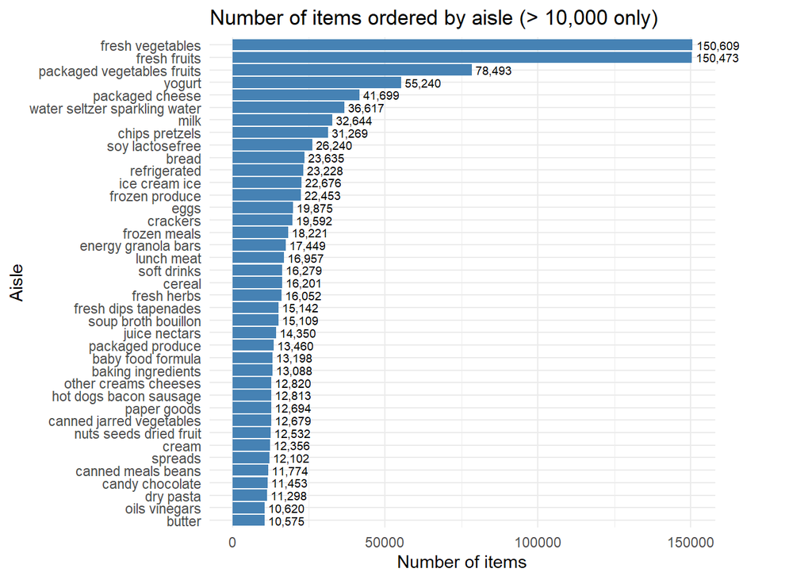

```r
aisle_plot_data =
  aisle_counts %>%
  filter(n_items > 10000) %>%
  mutate(aisle = forcats::fct_reorder(aisle, n_items))

aisle_plot =
  ggplot(aisle_plot_data, aes(x = aisle, y = n_items)) +
  geom_col(fill = "steelblue") +
  coord_flip(clip = "off") +
  geom_text(aes(label = scales::comma(n_items)),
            hjust = -0.1, size = 2.5) +
  labs(
    title = "Number of items ordered by aisle (> 10,000 only)",
    x = "Aisle",
    y = "Number of items") +
  theme_minimal() +
  theme(plot.margin = margin(5.5, 60, 5.5, 5.5))
aisle_plot
```

#### Popular items in some aisles:

```r
target_aisles = c("baking ingredients", "dog food care", "packaged vegetables fruits")

most_popular =
  instacart %>%
  filter(aisle %in% target_aisles) %>%
  group_by(aisle, product_name) %>%
  summarise(n = n(), .groups = "drop_last") %>%
  arrange(desc(n)) %>%
  group_by(aisle) %>%
  slice_max(order_by = n, n = 3, with_ties = FALSE) %>%
  mutate(rank = row_number()) %>%
  ungroup() %>%
  pivot_wider(
    id_cols   = aisle,
    names_from  = rank,
    values_from = c(product_name, n))

most_popular %>%
  knitr::kable(caption = "The three most popular items in the aisles")
```

The three most popular items in the aisles

| aisle | product_name_1 | product_name_2 | product_name_3 | n_1 | n_2 | n_3 |
| --- | --- | --- | --- | --- | --- | --- |
| baking ingredients | Light Brown Sugar | Pure Baking Soda | Cane Sugar | 499 | 387 | 336 |
| dog food care | Snack Sticks Chicken & Rice Recipe Dog Treats | Organix Chicken & Brown Rice Recipe | Small Dog Biscuits | 30 | 28 | 26 |
| packaged vegetables fruits | Organic Baby Spinach | Organic Raspberries | Organic Blueberries | 9784 | 5546 | 4966 |

#### Mean order hour during a week:

```r
dow_labs = c("Sun","Mon","Tue","Wed","Thu","Fri","Sat")

mean_hour_day=
  instacart %>%
  filter(product_name %in% c("Pink Lady Apples", "Coffee Ice Cream")) %>%
  mutate(order_dow = factor(order_dow, levels = 0:6, labels = dow_labs)) %>%
  group_by(product_name, order_dow) %>%
  summarise(mean_hour = mean(order_hour_of_day), .groups = "drop") %>%
  pivot_wider(
    names_from = order_dow,
    values_from = mean_hour
  )

mean_hour_day %>%
  knitr::kable(digits = 1, caption = "Mean order hour on each day of the week")
```

Mean order hour on each day of the week

| product_name | Sun | Mon | Tue | Wed | Thu | Fri | Sat |
| --- | --- | --- | --- | --- | --- | --- | --- |
| Coffee Ice Cream | 13.8 | 14.3 | 15.4 | 15.3 | 15.2 | 12.3 | 13.8 |
| Pink Lady Apples | 13.4 | 11.4 | 11.7 | 14.2 | 11.6 | 12.8 | 11.9 |

# Problem 2

### Import, clean, and tidy data:

```r
zip_code =
  read_csv("./zillow_data/Zip Codes.csv") %>%
  janitor::clean_names()
zip_zori =
  read_csv("./zillow_data/Zip_zori_uc_sfrcondomfr_sm_month_NYC.csv") %>%
  janitor::clean_names() %>%
  mutate(region_name = as.character(region_name))
zori_long =
  zip_zori %>%
  rename(zip_code = region_name) %>%
  pivot_longer(
    cols = matches("^x?\\d{4}[_-]\\d{2}([_-]\\d{2})?$"),
    names_to  = "date_raw",
    values_to = "rent"
  ) %>%
  mutate(
    date_raw = as.character(date_raw),
    date_raw = str_remove(date_raw, "^x"),
    date_raw = str_replace_all(date_raw, "_", "-"),
    date_raw = if_else(str_detect(date_raw, "^\\d{4}-\\d{2}$"),
                       paste0(date_raw, "-01"), date_raw),
    date = ymd(date_raw)
  ) %>%
  select(zip_code, date, rent) %>%
  drop_na(rent)
```

```r
zip_borough =
  zip_code %>%
  transmute(
    zip_code = as.character(zip_code),
    county   = str_to_lower(county) |>
               str_trim() |>
               str_replace("\\s+county$", "")) %>%
  mutate(
    borough = case_when(
      county == "new york"  ~ "Manhattan",
      county == "kings"      ~ "Brooklyn",
      county == "queens"     ~ "Queens",
      county == "bronx"      ~ "The Bronx",
      county == "richmond"   ~ "Staten Island",
      TRUE ~ NA_character_
    )) %>%
  select(zip_code, borough)
```

```r
zori <-
  zori_long %>%
  left_join(zip_borough, by = "zip_code",relationship = "many-to-many") %>%
  drop_na(borough)
zori
```

```
## # A tibble: 10,677 × 4
##    zip_code date        rent borough
##    <chr>    <date>     <dbl> <chr>
##  1 11368    2024-07-31 2322. Queens
##  2 11368    2024-08-31 2282. Queens
##  3 11385    2016-05-31 2266. Queens
##  4 11385    2016-06-30 2292. Queens
##  5 11385    2016-07-31 2321. Queens
##  6 11385    2016-08-31 2343. Queens
##  7 11385    2016-09-30 2337. Queens
##  8 11385    2016-10-31 2345. Queens
##  9 11385    2016-11-30 2320. Queens
## 10 11385    2016-12-31 2326. Queens
## # ℹ 10,667 more rows
```

### Answer some questions:

#### Zip code count:

```r
zip_count =
  zori_long %>%
  filter(date >= ymd("2015-01-01"), date <= ymd("2024-08-31")) %>%
  group_by(zip_code) %>%
  summarise(n_months = n_distinct(date), .groups = "drop") %>%
  summarise(zips_116 = sum(n_months == 116),
            zips_lt10 = sum(n_months < 10))
zip_count
```

```
## # A tibble: 1 × 2
##   zips_116 zips_lt10
##      <int>     <int>
## 1       48        26
```

Between January 2015 and August 2024, 48 ZIP codes are observed 116 times, while 26 ZIP codes are observed fewer than 10 times. This is because rarely observed ZIPs are typically boundary or newly created or retired ZIP codes, areas with very sparse listings, so they don’t receive a ZORI every month. However, well-covered ZIPs have consistent monthly data across the whole window.

#### Average rental price in brough and year:

```r
avg_price <-
  zori %>%
  group_by(borough, year = year(date)) %>%
  summarise(avg_rent = mean(rent, na.rm = TRUE), .groups = "drop") %>%
  mutate(borough = fct_relevel(borough, "Manhattan","Brooklyn","Queens","The Bronx","Staten Island")) %>%
  arrange(borough, year) %>%
  pivot_wider(names_from = year, values_from = avg_rent) %>%
  knitr::kable(digits = 0, caption = "Average rental price in each borough and year")

avg_price
```

Average rental price in each borough and year

| borough | 2015 | 2016 | 2017 | 2018 | 2019 | 2020 | 2021 | 2022 | 2023 | 2024 |
| --- | --- | --- | --- | --- | --- | --- | --- | --- | --- | --- |
| Manhattan | 3006 | 3015 | 3109 | 3160 | 3285 | 3091 | 3124 | 3753 | 3908 | 4053 |
| Brooklyn | 2493 | 2520 | 2546 | 2547 | 2631 | 2555 | 2550 | 2868 | 3015 | 3126 |
| Queens | 2215 | 2272 | 2263 | 2292 | 2388 | 2316 | 2211 | 2406 | 2562 | 2694 |
| The Bronx | 1760 | 1520 | 1544 | 1639 | 1706 | 1811 | 1858 | 2054 | 2285 | 2497 |
| Staten Island | NA | NA | NA | NA | NA | 1978 | 2045 | 2147 | 2333 | 2536 |

#### Plot for rental price within ZIP code：

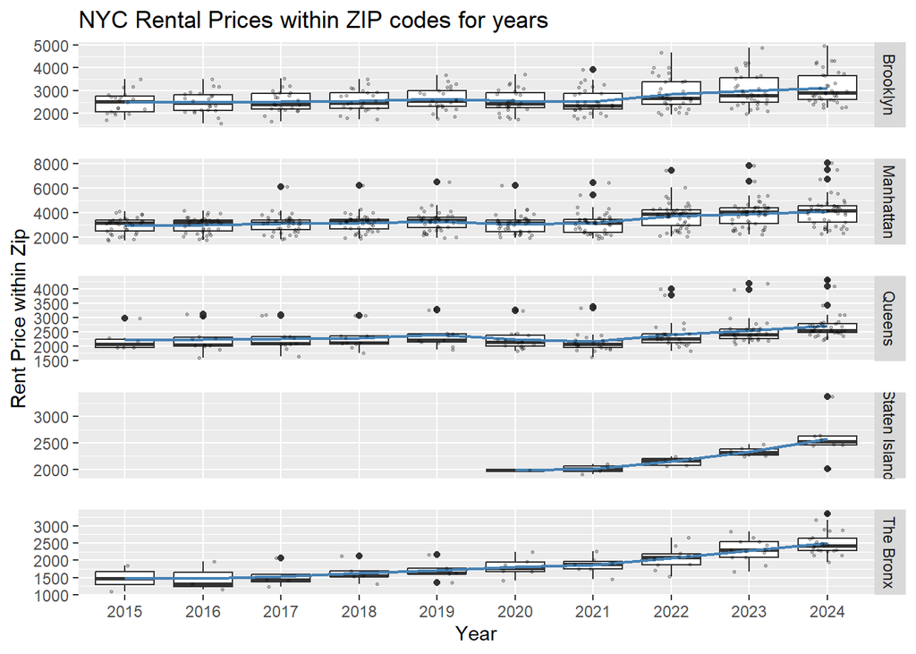

```r
zip_year =
  zori %>%
  group_by(borough, zip_code, year = year(date)) %>%
  summarise(rent_year_zip = mean(rent, na.rm = TRUE), .groups = "drop")

borough_year =
  zip_year %>%
  group_by(borough, year) %>%
  summarise(mean_rent = mean(rent_year_zip), .groups = "drop")

price_zip_plot =
  ggplot(zip_year, aes(x = factor(year), y = rent_year_zip)) +
  geom_boxplot() +
  geom_line(
    data = borough_year,
    aes(y = mean_rent, group = 1),
    linewidth = 0.8, color = "steelblue") +
  geom_jitter(width = 0.25, height = 0, alpha = 0.25, size = 0.6) +
  facet_grid(borough ~ ., scales = "free_y") +
  labs(title = "NYC Rental Prices within ZIP codes for years", x= "Year", y = "Rent Price within Zip") +
  theme(panel.spacing.y = unit(1.2, "lines"))

price_zip_plot
```

Rental prices vary across boroughs, with annual rental changes consistent with the findings from the previous question. Additionally, rental prices in Brooklyn and Manhattan exhibit a broader distribution within zip codes.

#### Plot for rental price in 2023：

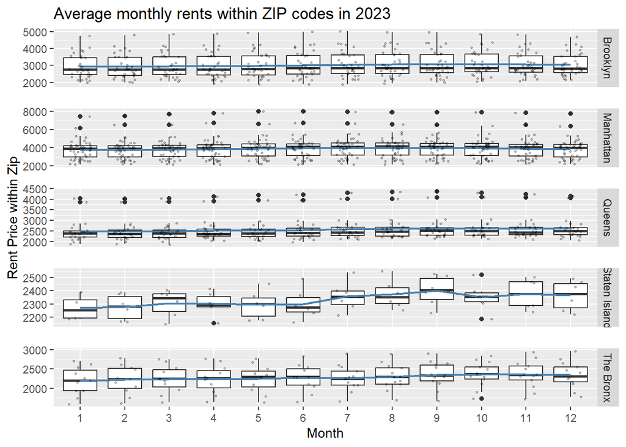

```r
rent_2023 =
  zori %>%
  filter(year(date) == 2023) %>%
  mutate(mon_num = month(date),
         mon_f   = factor(mon_num, levels = 1:12, labels = 1:12)) %>%
  group_by(borough, zip_code, mon_f) %>%
  summarise(avg_rent = mean(rent, na.rm = TRUE), .groups = "drop")


borough_month =
  rent_2023 %>%
  group_by(borough, mon_f) %>%
  summarise(mean_rent = mean(avg_rent), .groups = "drop")

price_zip_2023 =
  ggplot(rent_2023, aes(x = mon_f, y = avg_rent)) +
  geom_boxplot() +
  geom_line(data = borough_month,
            aes(y = mean_rent, group = 1),
            linewidth = 0.8, color = "steelblue") +
  geom_jitter(width = 0.25, height = 0, alpha = 0.25, size = 0.6) +
  facet_grid(borough ~ ., scales = "free_y") +
  labs(title = "Average monthly rents within ZIP codes in 2023",
       x = "Month", y = "Rent Price within Zip") +
  theme(panel.spacing.y = unit(1.2, "lines"))

price_zip_2023
```

#### Combine the plots:

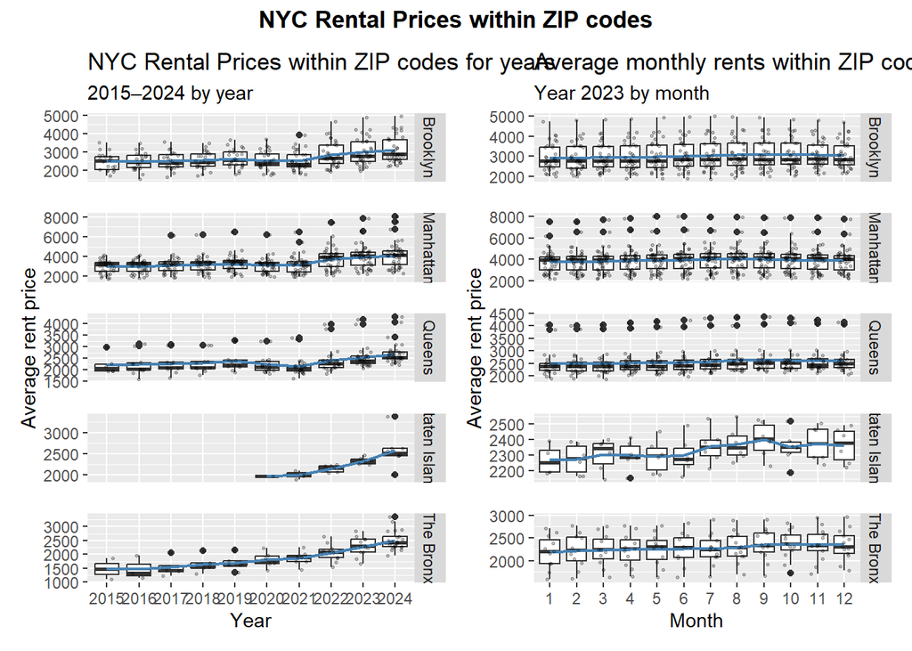

```r
left  = price_zip_plot  +
  labs(subtitle = "2015–2024 by year", y = "Average rent price")

right = price_zip_2023  +
  labs(subtitle = "Year 2023 by month", y = "Average rent price")

combined_plot =
  (left | right) +
  plot_layout(widths = c(1, 1)) +
  plot_annotation(
    title = "NYC Rental Prices within ZIP codes",
    theme = theme(plot.title = element_text(hjust = 0.5, face = "bold"))
  )

combined_plot
```

```r
ggsave("results/nyc rents sum plot.png", combined_plot,
       width = 16, height = 12, units = "in", dpi = 300, bg = "white")
```

# Problem 3

### Load, tidy, merge, and organize dataset:

```r
accel =
  read_csv("./MIMS/nhanes_accel.csv") %>%
  janitor::clean_names()
covar =
  read_csv("./MIMS/nhanes_covar.csv", skip = 4, show_col_types = FALSE) %>%
  janitor::clean_names()


covar_filter =
  covar %>%
  filter(age >= 21) %>%
  drop_na() %>%
  mutate(
    sex = if (is.numeric(sex))
            factor(sex, levels = c(1, 2), labels = c("Male", "Female"))
          else factor(sex),
    education = if (is.numeric(education))
                  factor(education, levels = c(1, 2, 3),
                         labels = c("Less than HS", "HS equivalent", "More than HS"),
                         ordered = TRUE)
                else factor(education, ordered = TRUE))
covar_filter
```

```
## # A tibble: 228 × 5
##     seqn sex      age   bmi education
##    <dbl> <fct>  <dbl> <dbl> <ord>
##  1 62161 Male      22  23.3 HS equivalent
##  2 62164 Female    44  23.2 More than HS
##  3 62169 Male      21  20.1 HS equivalent
##  4 62174 Male      80  33.9 More than HS
##  5 62177 Male      51  20.1 HS equivalent
##  6 62178 Male      80  28.5 HS equivalent
##  7 62180 Male      35  27.9 More than HS
##  8 62184 Male      26  22.1 HS equivalent
##  9 62189 Female    30  22.4 More than HS
## 10 62199 Male      57  28   More than HS
## # ℹ 218 more rows
```

If we need combined dataset:

```r
combined_data =
  covar_filter %>%
  inner_join(accel, by = "seqn", relationship = "one-to-one")
```

### sex and education category:

```r
edu_sex_tab =
  covar_filter %>%
  count(education, sex, name = "n") %>%
  group_by(education) %>%
  pivot_wider(names_from = sex, values_from = n,values_fill = 0)

knitr::kable(edu_sex_tab, caption = "Number of men and women in each education category")
```

Number of men and women in each education category

| education | Male | Female |
| --- | --- | --- |
| Less than HS | 27 | 28 |
| HS equivalent | 35 | 23 |
| More than HS | 56 | 59 |

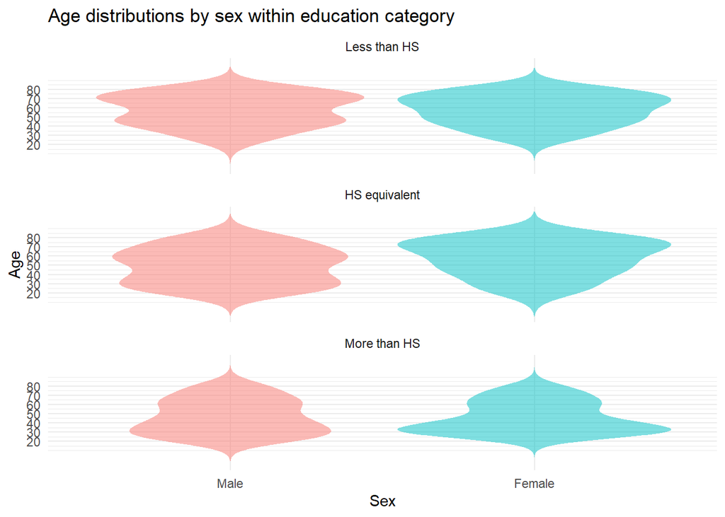

```r
age_distri_plot =
  covar_filter %>%
  ggplot(aes(x = sex, y = age, fill = sex)) +
  geom_violin(width = 0.9, trim = FALSE, alpha = 0.5,
              position = position_dodge(width = 0.8), color = NA) +
  facet_wrap(~ education, ncol = 1) +
  labs(
    title = "Age distributions by sex within education category",
    x = "Sex", y = "Age") +
  scale_y_continuous(breaks = seq(20, 80, 10)) +
  theme_minimal() +
  theme(legend.position = "none")

age_distri_plot
```

The table shows that the total gender distribution across different educational levels is relatively balanced. Further examination of the age distribution plot by gender within each educational category reveals that low educational levels are concentrated among older age groups, while those with education beyond high school are mainly concentrated among younger individuals. Among those with a high school education, males exhibit a broader age distribution, whereas females show a higher proportion in middle-aged and older groups. Overall, educational level is related to age but not significantly to gender. This phenomenon may be due to the increasing accessibility of higher education in recent years.

### Total activity:

```r
minute_cols = grep("^min\\d+$", names(accel), value = TRUE)

total_activ =
  accel %>%
  dplyr::mutate(total_activity = rowSums(dplyr::select(., dplyr::all_of(minute_cols)),
                                         na.rm = TRUE)) %>%
  dplyr::select(seqn, total_activity)


final_data =
  covar_filter %>%
  inner_join(total_activ, by = "seqn", relationship = "one-to-one")
final_data
```

```
## # A tibble: 228 × 6
##     seqn sex      age   bmi education     total_activity
##    <dbl> <fct>  <dbl> <dbl> <ord>                  <dbl>
##  1 62161 Male      22  23.3 HS equivalent         13194.
##  2 62164 Female    44  23.2 More than HS          13411.
##  3 62169 Male      21  20.1 HS equivalent          9991.
##  4 62174 Male      80  33.9 More than HS           8579.
##  5 62177 Male      51  20.1 HS equivalent         11918.
##  6 62178 Male      80  28.5 HS equivalent          7489.
##  7 62180 Male      35  27.9 More than HS          14205.
##  8 62184 Male      26  22.1 HS equivalent         13599.
##  9 62189 Female    30  22.4 More than HS          18551.
## 10 62199 Male      57  28   More than HS          14548.
## # ℹ 218 more rows
```

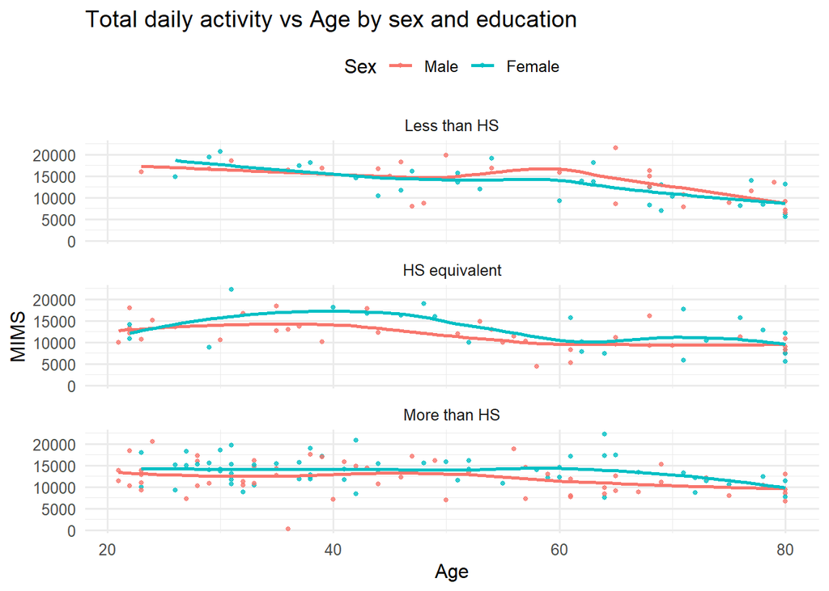

```r
activ_plot =
  ggplot(final_data, aes(x = age, y = total_activity, color = sex)) +
  geom_point(alpha = 0.8, size = 1) +
  geom_smooth(se = FALSE, method = "loess", linewidth = 1) +
  facet_wrap(~ education, ncol = 1) +
  labs(
    title = "Total daily activity vs Age by sex and education",
    x = "Age",
    y = "MIMS",
    color = "Sex") +
  theme_minimal(base_size = 12) +
  theme(legend.position = "top")
activ_plot
```

As shown in the plot, MIMS declines with increasing age. By gender, women generally exhibit slightly higher MIMS than men, except in the group with less than a high school education, where middle-aged and older men show slightly higher MIMS than women. The overall activity levels across the three education groups are generally comparable. Overall, in this sample, age is the primary factor driving the decline in activity levels; differences attributable to gender and education level are relatively slight.

### 24-hour activity time courses:

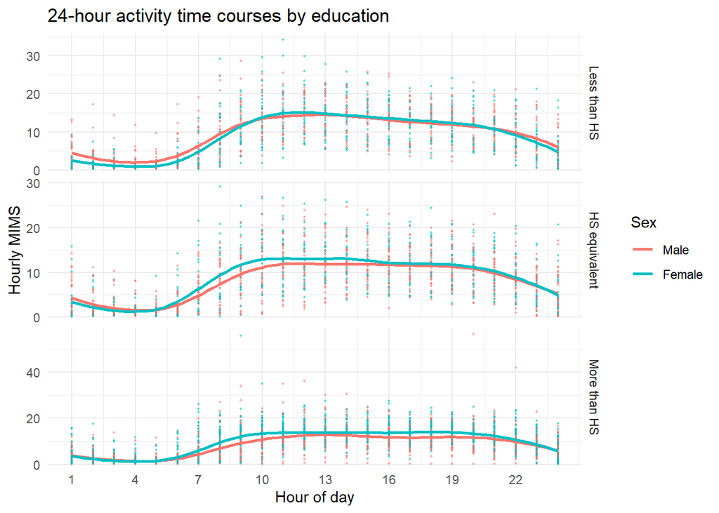

```r
minute_cols = grep("^min\\d+$", names(combined_data), value = TRUE)

hour_activ =
  combined_data %>%
  pivot_longer(all_of(minute_cols), names_to = "minute", values_to = "mims") %>%
  mutate(
    minute_num = as.integer(str_remove(minute, "^min")),
    hour = floor((minute_num - 1) / 60) +1 ) %>%
  group_by(seqn, sex, age, bmi, education, hour) %>%
  summarise(mims_hour = mean(mims, na.rm = TRUE), .groups = "drop")

day_activ_plot =
  ggplot(hour_activ, aes(x = hour, y = mims_hour, color = sex)) +
  geom_point(alpha = 0.5, size = 0.4) +
  geom_smooth(se = FALSE, method = "loess", span = 0.3, linewidth = 1) +
  facet_grid(rows = vars(education), scales = "free_y") +
  scale_x_continuous(breaks = seq(1, 24, by = 3), limits = c(1, 24)) +
  scale_y_continuous(limits = c(0, NA), expand = expansion(mult = c(0.02, 0.05))) +
  labs(title = "24-hour activity time courses by education",
       x = "Hour of day", y = "Hourly MIMS", color = "Sex") +
  theme_minimal()
day_activ_plot
```

The daily activity level trajectory shows that MMS is lowest in the early morning, gradually rising from around 6 to 7 a.m., peaking at noon, and remaining high throughout the afternoon before declining significantly around 8 to 10 p.m. This daily activity pattern is consistent with human circadian rhythms. The shape of the curve is similar across different educational levels. Women’s curves are generally slightly higher than men’s during daytime hours.